# Cyclistic Market Data Analysis

Eric Slack

2025-03-21

## Differences in Service Usage Between Casual Riders and Annual Members

The Cyclistic marketing analytics team has been tasked with determining a marketing strategy to help convert casual riders to annual membership plans. In this portion we will be discussing our starting point of how casual riders and annual members use the service differently.

### Data Source

Our data comes from actual ride data, without any personally identifying information, from 12/2023 to 11/2024. We have removed from the raw data the rides that do not start and end at a station, as the process for checking out a bike requires that it both start and end locked into a station. Additional columns were added to compute the ride duration, the starting hour, the day of the week, and the day of the month for each ride.

### Analysis

From this chart, we can see that there are no significant seasonal differences between members and casual riders.

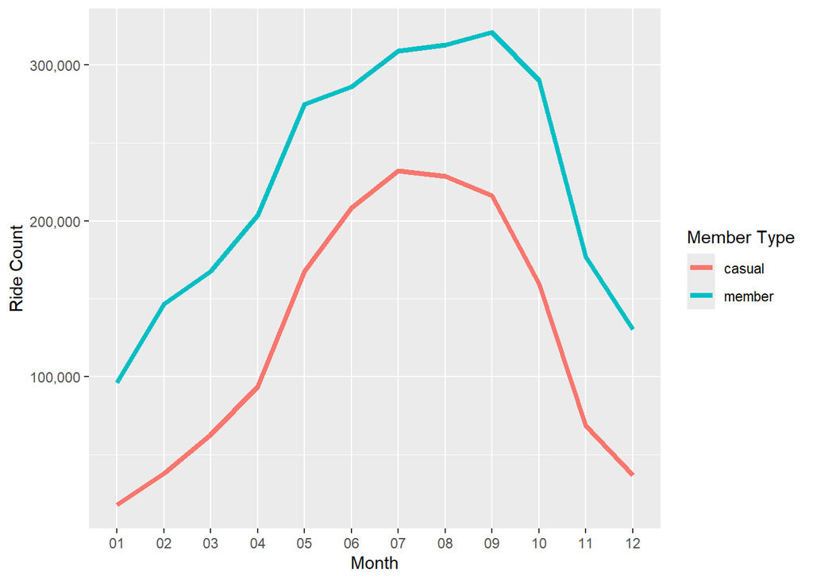

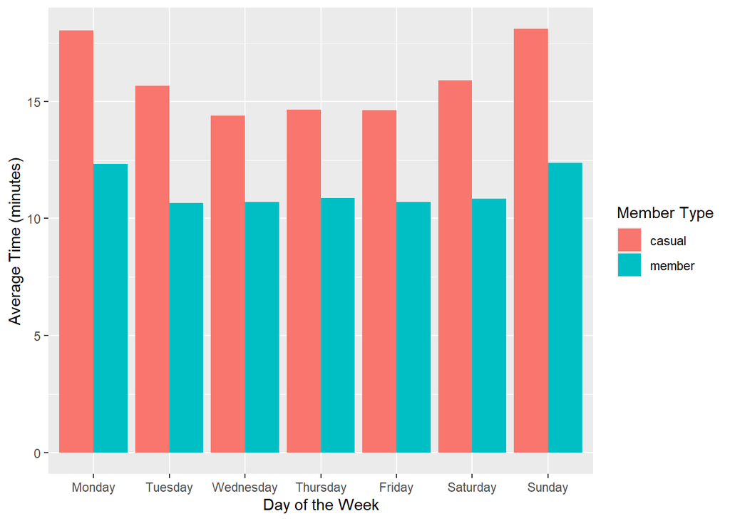

There doesn’t seem to be much of a difference between members and casual riders on which type of device is chosen, with the exception that casual riders were slightly more likely to choose an electric scooter than members.

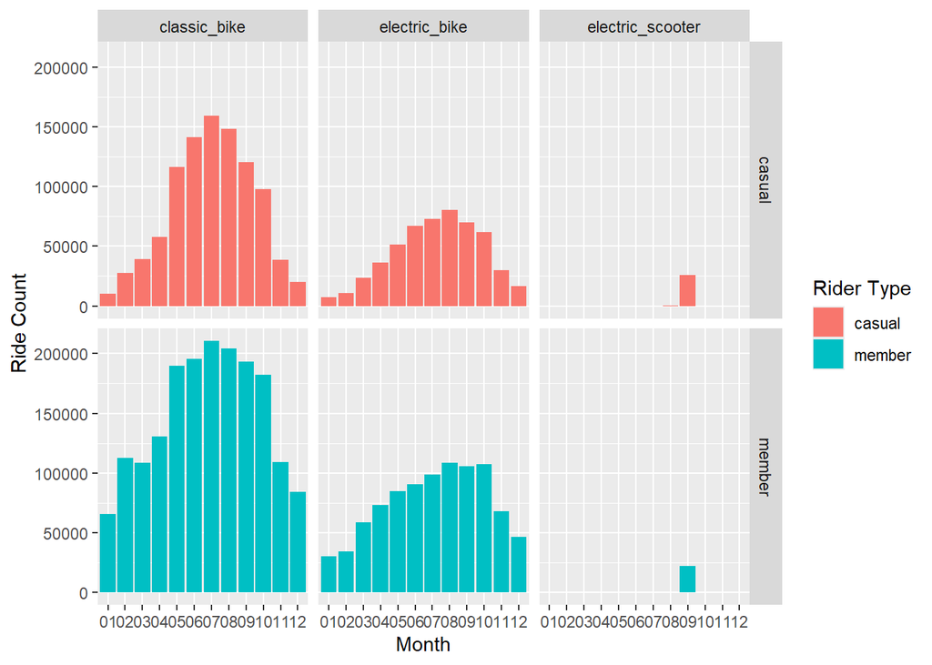

The most striking difference was the start times of the rides on each day of the week. This shows that while casual and member rides are fairly even on weekends, there is a major jump in the number of members using bikes during the week, especially at daily commute times.

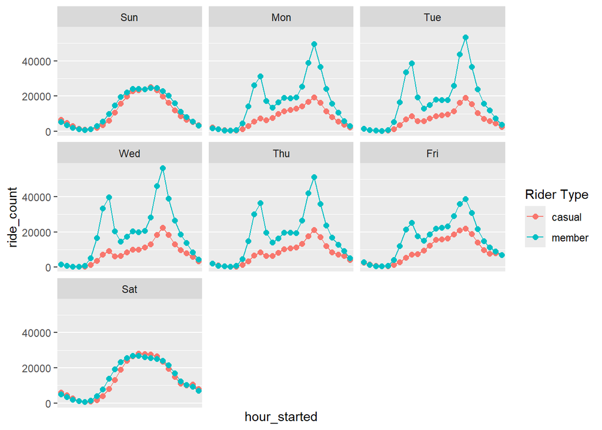

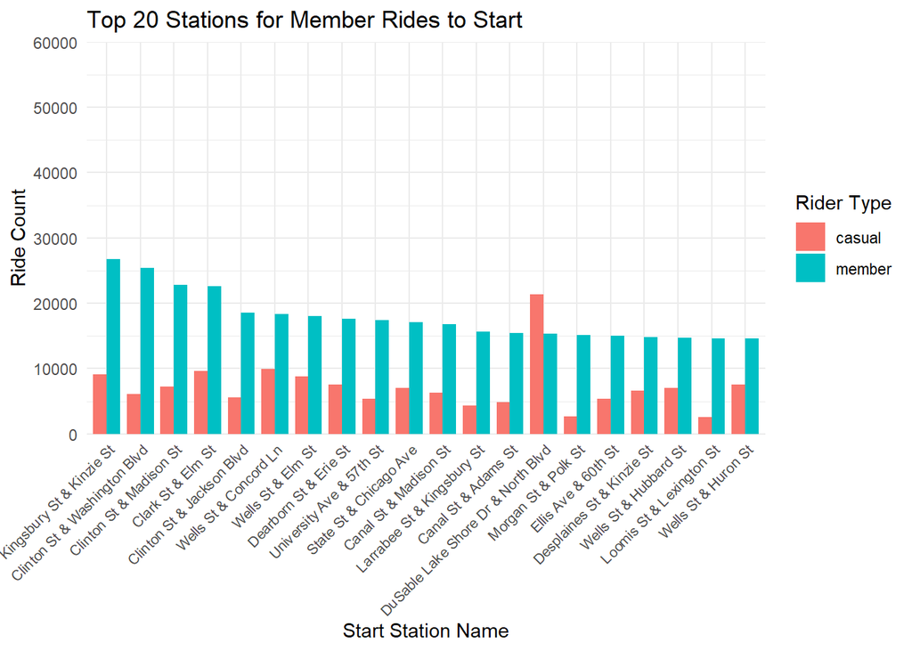

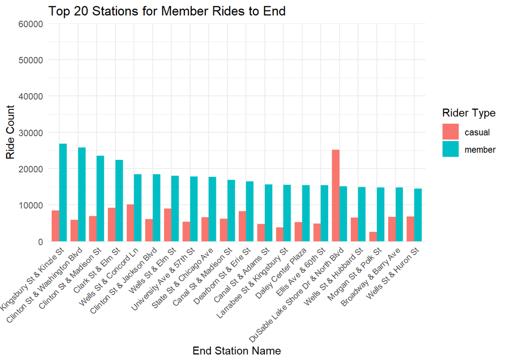

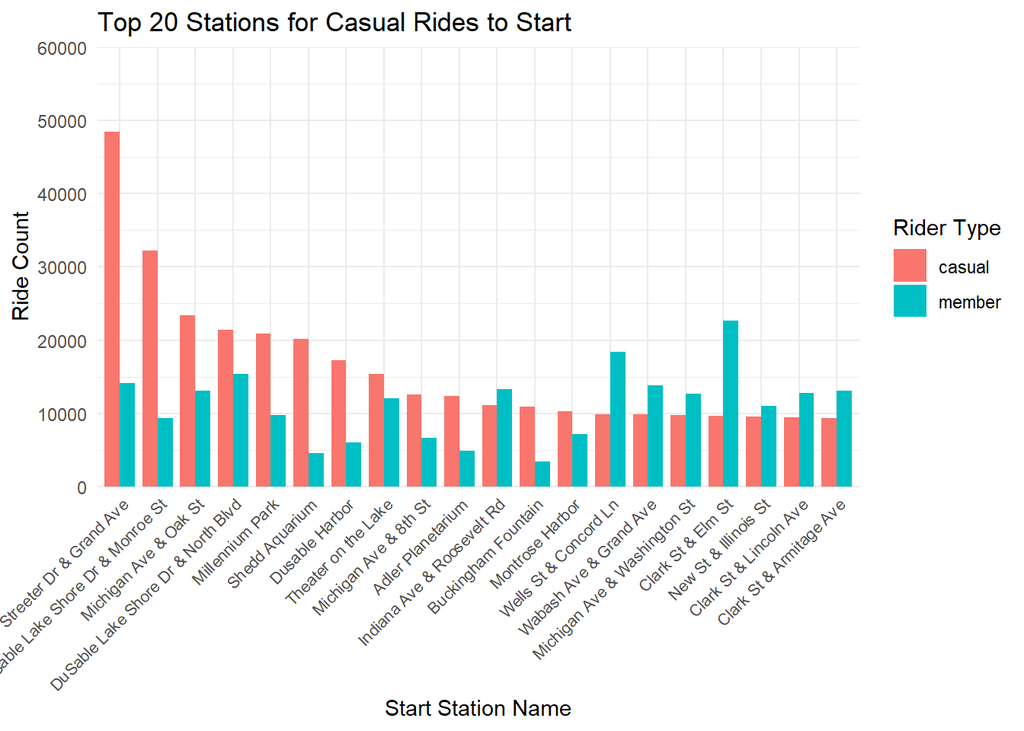

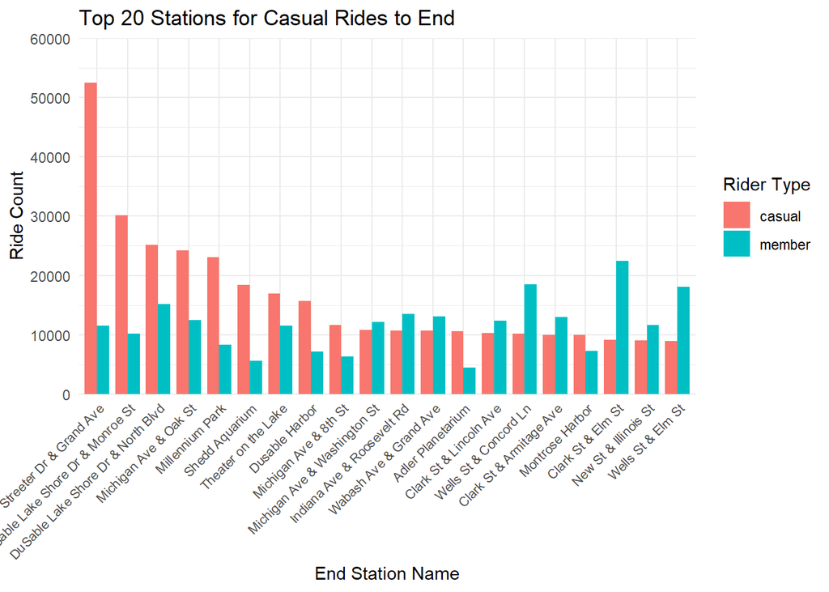

### Recommendations

My recommendations from this analysis would be to focus on areas of the city that are frequented by casual riders more often, target ads to those who take longer rides, and to encourage using the service for commuting as well as recreation.